# Exploring the BRFSS data

## Setup

### Load packages

```r
library(ggplot2)
library(dplyr)
```

### Load data

```r
load("brfss2013.RData")
```

#### Part 1: About the Data

The Behavioral Risk Factor Surveillance System (BRFSS) is an annual telephone survey in the United States.BRFSS is an ongoing surveillance system designed to measure behavioral risk factors for the non-institutionalized adult population (18 years of age and older) residing in the US. The objective of BRFSS is to find homogeneous, state specific data residing in the US on preventive health practices and risk behaviors that are related to chronic diseases.

**Data Collection:**

Data has been collected randomly has been shown in the BRFSS Codebook via land line telephone- and cellular telephone-based survey.

**Possible Biases:**

The data has been collected from the people who were randomly selected and were accessible to attend the phone calls hence, there is a chance that there is a convenience bias in the sample.

**Causation:**

The sample given is an observational sample and thus there is no causation, only correlation or association can be drawn.

**Generalizability:**

The sample is drawn using random sampling, hence we can say that the given sample is generalizable to the population, or the sample is a representative sample.

#### Part 2: Research questions

**Research question 1:** Is there any association between employment status and not being able to see doctor because of the cost?

**Research question 2:** Is there any association between having told that they have Arthritis, Ever being told you had a depressive disorder to being a veteran?

**Research question 3:** Is there any association with chronic health conditions like being diagnosed with heart attack, being diagnosed with Angina or Coronary Heart disease or being diagnosed with a stroke with Average Alcoholic drinks had per day in past 30 days?

#### Part 3: Exploratory data analysis

**Research question 1:** Is there any association between employment status and not being able to see doctor because of the cost?

Variables used for this question: employ1 - Employment Status medcost - Could not see doctor because of cost

```r
employ_med <- brfss2013 %>%
  filter(!is.na(employ1),!is.na(medcost))%>%
  select(employ1 , medcost)
```

We can visualize our given data over here:

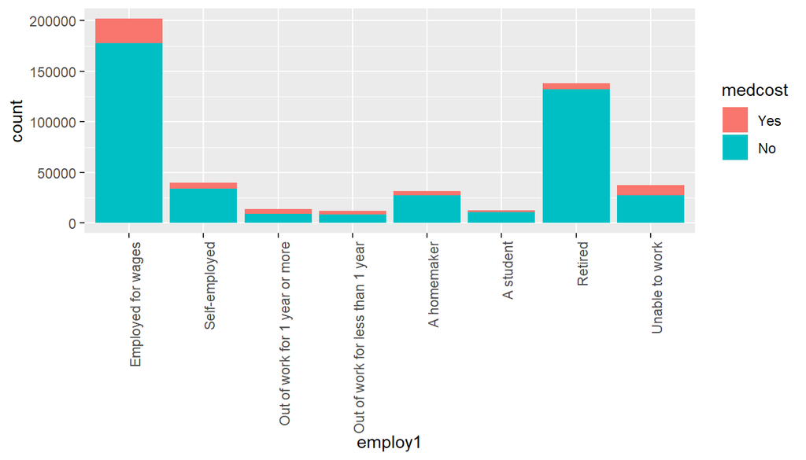

```r
ggplot(employ_med,aes(x= employ1, fill=medcost))+geom_bar()+theme(axis.text.x = element_text(angle = 90, hjust = 1))
```

```r
by(employ_med$medcost, employ_med$employ1, summary)
```

```
## employ_med$employ1: Employed for wages
##    Yes     No
##  23913 177977
## --------------------------------------------------------
## employ_med$employ1: Self-employed
##   Yes    No
##  5597 34142
## --------------------------------------------------------
## employ_med$employ1: Out of work for 1 year or more
##  Yes   No
## 4709 9302
## --------------------------------------------------------
## employ_med$employ1: Out of work for less than 1 year
##  Yes   No
## 3831 8375
## --------------------------------------------------------
## employ_med$employ1: A homemaker
##   Yes    No
##  4073 27487
## --------------------------------------------------------
## employ_med$employ1: A student
##   Yes    No
##  1918 10728
## --------------------------------------------------------
## employ_med$employ1: Retired
##    Yes     No
##   5905 132018
## --------------------------------------------------------
## employ_med$employ1: Unable to work
##   Yes    No
##  9668 27581
```

In general, we can see that the people who are unemployed for a year or more and the people who are unemployed for less than a year and the people who are unable to work are more likely that they could not visit the doctor because of the cost.

**Research question 2:**

We need to find if there is any association between having arthritis or depressive disorder and being a veteran.

The variables we will use are: addepev2 - Ever Told You Had A Depressive Disorder, havarth3: Told Have Arthritis, veteran3: Are You A Veteran

```r
veteran <- brfss2013 %>%
        # omitting NAs
        filter(!is.na(havarth3), !is.na(addepev2), !is.na(veteran3) )%>%
        select(havarth3, addepev2, veteran3)
```

Since, the values for havarth3 and addepev2 are categorical and have yes or no values we will convert the values in true or false.

```r
veteran<- veteran %>%
  mutate(havarth3 = ifelse(veteran$havarth3 =="Yes",TRUE,FALSE))
veteran<- veteran %>%
  mutate(addepev2 = ifelse(veteran$addepev2 == "Yes",TRUE,FALSE))
veteran<- veteran %>%
  mutate(veteran3 = ifelse(veteran$veteran3 == "Yes",TRUE,FALSE))
```

We need to only check for data when person being veteran

```r
veteran<- veteran %>%
  filter(veteran3=="TRUE")
```

Now we can visualize our data for having Arthritis and being a veteran.

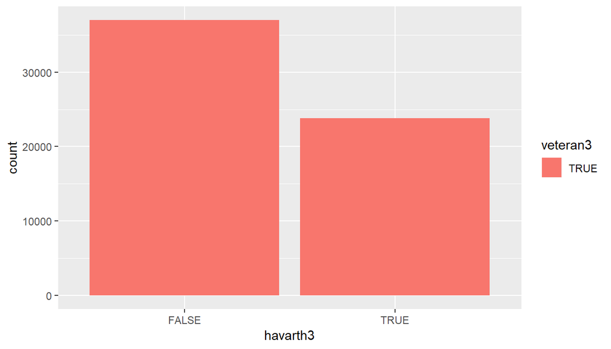

```r
ggplot(veteran, aes(x = havarth3, fill = veteran3))+geom_bar()
```

```r
by(veteran$havarth3, veteran$veteran3, summary)
```

```
## veteran$veteran3: TRUE
##    Mode   FALSE    TRUE
## logical   36969   23782
```

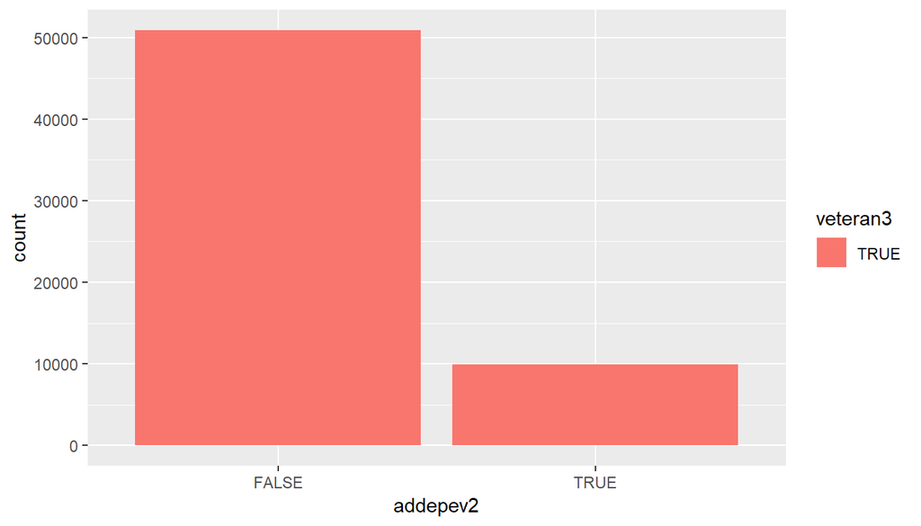

```r
ggplot(veteran, aes(x = addepev2, fill = veteran3))+geom_bar()
```

```r
by(veteran$addepev2, veteran$veteran3, summary)
```

```
## veteran$veteran3: TRUE
##    Mode   FALSE    TRUE
## logical   50864    9887
```

**Research question 3:**

Is there any association with chronic health conditions like being diagnosed with heart attack, being diagnosed with Angina or Coronary Heart disease or being diagnosed with a stroke with Average Alcoholic drinks had per day in past 30 days?

The variables we will use are: cvdinfr4: Ever Diagnosed With Heart Attack, cvdcrhd4: Ever Diagnosed With Angina Or Coronary Heart Disease, cvdstrk3: Ever Diagnosed With A Stroke, avedrnk2: Average Alcoholic Drinks per day in past 30 days

First, we will remove all the N/A values from out results

```r
alcohol <- brfss2013 %>%
        # omitting NAs
        filter(!is.na(cvdinfr4), !is.na(cvdcrhd4), !is.na(cvdstrk3), !is.na(avedrnk2))%>%
        select(cvdinfr4, cvdcrhd4, cvdstrk3,avedrnk2 )
```

Our given data is in categorical form, we need to convert our given data in TRUE or FALSE

```r
alcohol<- alcohol %>%
  mutate(cvdinfr4 = ifelse(alcohol$cvdinfr4 =="Yes",TRUE,FALSE))
alcohol<- alcohol %>%
  mutate(cvdcrhd4 = ifelse(alcohol$cvdcrhd4 == "Yes",TRUE,FALSE))
alcohol<- alcohol %>%
  mutate(cvdstrk3 = ifelse(alcohol$cvdstrk3 == "Yes",TRUE,FALSE))
```

We can now visualize our data of being diagonosed with heart attack and max drinks in past 30 days

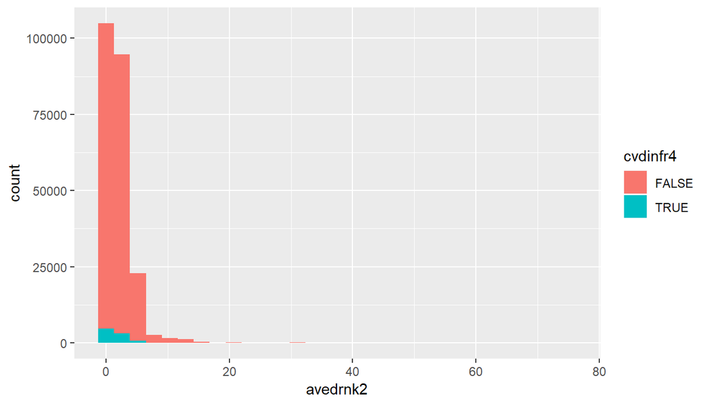

```r
ggplot(alcohol, aes(x =avedrnk2, fill =cvdinfr4))+geom_histogram(bins=30)
```

```r
by(alcohol$cvdinfr4,alcohol$avedrnk2,summary)
```

```
## alcohol$avedrnk2: 1
##    Mode   FALSE    TRUE
## logical  100211    4626
## --------------------------------------------------------
## alcohol$avedrnk2: 2
##    Mode   FALSE    TRUE
## logical   66415    2363
## --------------------------------------------------------
## alcohol$avedrnk2: 3
##    Mode   FALSE    TRUE
## logical   25018     855
## --------------------------------------------------------
## alcohol$avedrnk2: 4
##    Mode   FALSE    TRUE
## logical   10706     353
## --------------------------------------------------------
## alcohol$avedrnk2: 5
##    Mode   FALSE    TRUE
## logical    5825     172
## --------------------------------------------------------
## alcohol$avedrnk2: 6
##    Mode   FALSE    TRUE
## logical    5617     226
## --------------------------------------------------------
## alcohol$avedrnk2: 7
##    Mode   FALSE    TRUE
## logical     923      32
## --------------------------------------------------------
## alcohol$avedrnk2: 8
##    Mode   FALSE    TRUE
## logical    1456      46
## --------------------------------------------------------
## alcohol$avedrnk2: 9
##    Mode   FALSE    TRUE
## logical     205       5
## --------------------------------------------------------
## alcohol$avedrnk2: 10
##    Mode   FALSE    TRUE
## logical    1459      39
## --------------------------------------------------------
```

[output cut: 136 more lines]

```
## alcohol$avedrnk2: 70
##    Mode   FALSE
## logical       3
## --------------------------------------------------------
## alcohol$avedrnk2: 72
##    Mode   FALSE
## logical       1
## --------------------------------------------------------
## alcohol$avedrnk2: 75
##    Mode   FALSE
## logical       1
## --------------------------------------------------------
## alcohol$avedrnk2: 76
##    Mode   FALSE    TRUE
## logical       6       1
```

Now, we can now visualize our data of being diagonosed with Angina or Coronary Heart Disease with max drinks in past 30 days

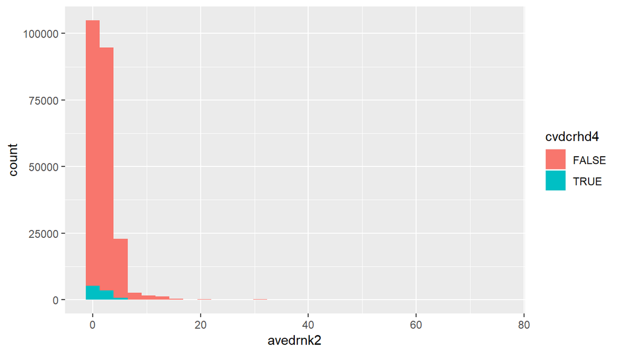

```r
ggplot(alcohol, aes(x =avedrnk2, fill =cvdcrhd4))+geom_histogram(bins=30)
```

```r
by(alcohol$cvdcrhd4,alcohol$avedrnk2,summary)
```

```
## alcohol$avedrnk2: 1
##    Mode   FALSE    TRUE
## logical   99560    5277
## --------------------------------------------------------
## alcohol$avedrnk2: 2
##    Mode   FALSE    TRUE
## logical   66129    2649
## --------------------------------------------------------
## alcohol$avedrnk2: 3
##    Mode   FALSE    TRUE
## logical   25021     852
## --------------------------------------------------------
## alcohol$avedrnk2: 4
##    Mode   FALSE    TRUE
## logical   10694     365
## --------------------------------------------------------
## alcohol$avedrnk2: 5
##    Mode   FALSE    TRUE
## logical    5841     156
## --------------------------------------------------------
## alcohol$avedrnk2: 6
##    Mode   FALSE    TRUE
## logical    5666     177
## --------------------------------------------------------
## alcohol$avedrnk2: 7
##    Mode   FALSE    TRUE
## logical     930      25
## --------------------------------------------------------
## alcohol$avedrnk2: 8
##    Mode   FALSE    TRUE
## logical    1458      44
## --------------------------------------------------------
## alcohol$avedrnk2: 9
##    Mode   FALSE    TRUE
## logical     204       6
## --------------------------------------------------------
## alcohol$avedrnk2: 10
##    Mode   FALSE    TRUE
## logical    1467      31
## --------------------------------------------------------
```

[output cut: 136 more lines]

```
## alcohol$avedrnk2: 70
##    Mode   FALSE
## logical       3
## --------------------------------------------------------
## alcohol$avedrnk2: 72
##    Mode   FALSE
## logical       1
## --------------------------------------------------------
## alcohol$avedrnk2: 75
##    Mode   FALSE
## logical       1
## --------------------------------------------------------
## alcohol$avedrnk2: 76
##    Mode   FALSE    TRUE
## logical       6       1
```

Now, we can now visualize our data of being diagonosed with Stroke with max drinks in past 30 days

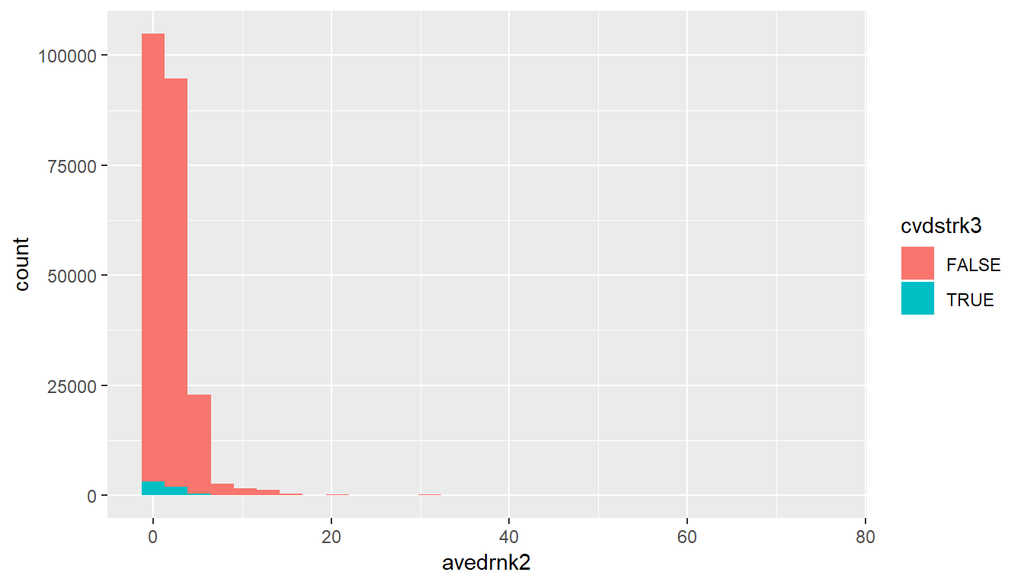

```r
ggplot(alcohol, aes(x =avedrnk2, fill =cvdstrk3))+geom_histogram(bins=30)
```

```r
by(alcohol$cvdstrk3,alcohol$avedrnk2,summary)
```

```
## alcohol$avedrnk2: 1
##    Mode   FALSE    TRUE
## logical  101783    3054
## --------------------------------------------------------
## alcohol$avedrnk2: 2
##    Mode   FALSE    TRUE
## logical   67329    1449
## --------------------------------------------------------
## alcohol$avedrnk2: 3
##    Mode   FALSE    TRUE
## logical   25424     449
## --------------------------------------------------------
## alcohol$avedrnk2: 4
##    Mode   FALSE    TRUE
## logical   10847     212
## --------------------------------------------------------
## alcohol$avedrnk2: 5
##    Mode   FALSE    TRUE
## logical    5891     106
## --------------------------------------------------------
## alcohol$avedrnk2: 6
##    Mode   FALSE    TRUE
## logical    5724     119
## --------------------------------------------------------
## alcohol$avedrnk2: 7
##    Mode   FALSE    TRUE
## logical     936      19
## --------------------------------------------------------
## alcohol$avedrnk2: 8
##    Mode   FALSE    TRUE
## logical    1473      29
## --------------------------------------------------------
## alcohol$avedrnk2: 9
##    Mode   FALSE    TRUE
## logical     205       5
## --------------------------------------------------------
## alcohol$avedrnk2: 10
##    Mode   FALSE    TRUE
## logical    1477      21
## --------------------------------------------------------
```

[output cut: 136 more lines]

```
## alcohol$avedrnk2: 70
##    Mode   FALSE
## logical       3
## --------------------------------------------------------
## alcohol$avedrnk2: 72
##    Mode   FALSE
## logical       1
## --------------------------------------------------------
## alcohol$avedrnk2: 75
##    Mode   FALSE
## logical       1
## --------------------------------------------------------
## alcohol$avedrnk2: 76
##    Mode   FALSE    TRUE
## logical       6       1
```

The above figures show that there is no significant effect of number of drinks taken in past month on being diagnosed with Heart Attack, Angina or Coronary Heart Disease, or having a stroke.